# Supervised Learning and Visualization Practical 5

# Visualising the effect of the balance variable

12. Create a data frame called balance_df with 3 columns and 500 rows: student always 0, balance ranging from 0 to 3000, and income always the mean income in the default_train dataset.

```r
balance_df <- tibble(student = rep(0, 500),
                     balance = seq(0,3000, length.out = 500),
                     income = rep(mean(default_train$income), 500))
```

13. Use this dataset as the newdata in a predict() call using lr_mod to output the predicted probabilities for different values of balance. Then create a plot with the balance_df$balance variable mapped to x and the predicted probabilities mapped to y. Is this in line with what you expect?

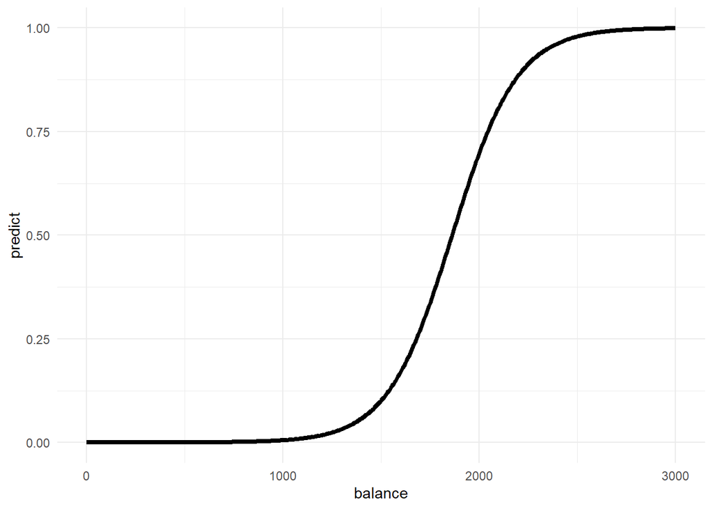

```r
balance_df$predict <- predict(lr_mod, newdata = balance_df, type = "response")

balance_df %>% ggplot(aes(x = balance, y = predict))+
  geom_line(size = 1.5)+
  theme_minimal()
```

14. Create a confusion matrix just as the one for the KNN models by using a cutoff predicted probability of 0.5. Does logistic regression perform better?

```r
# turn probs into 0,1
default_test$predicted <- predict(lr_mod, newdata = default_test, type = 'response')
default_test$predicted <-ifelse(default_test$predicted >= .5, "Yes", "No")

# confusion matrix
table(true = default_test$default, predicted = default_test$predicted)
```

```
##      predicted
## true    No  Yes
##   No  1921   12
##   Yes   43   24
```

```r
# remove predictions from previous models
default_test <- default_test
```

# Linear discriminant analysis

15. Train an LDA classifier lda_mod on the training set.

```r
lda_mod <- lda(default ~ ., data = default_train)
```

16. Look at the lda_mod object. What can you conclude about the characteristics of the people who default on their loans?

```r
lda_mod
```

```
## Call:
## lda(default ~ ., data = default_train)
##
## Prior probabilities of groups:
##      No     Yes
## 0.96675 0.03325
##
## Group means:
##       student   balance   income
## No  0.2922162  805.3601 33577.25
## Yes 0.3984962 1757.2081 31668.13
##
## Coefficients of linear discriminants:
##                     LD1
## student -0.139709826769
## balance  0.002245907993
## income   0.000003293756
```

17. Create a confusion matrix and compare it to the previous methods.

```r
default_test$predicted <- predict(lda_mod, newdata = default_test)$class
table(true = default_test$default, predicted = default_test$predicted)
```

```
##      predicted
## true    No  Yes
##   No  1925    8
##   Yes   51   16
```

Compared to logistic regression, we see fewer True Positives. The remaining statistics are similar. However, in this task we should prioritize true-positive-detection. For this reason, I prefer logistic regression.

18. Create a model (using knn, logistic regression, or LDA) to predict whether a 14 year old boy from the 3rd class would have survived the Titanic disaster. You can find the data in the data/ folder. Would the passenger have survived if they were a girl in 2nd class?

For this I will use the whole data to train the model as we are not interested in predicting new cases as much as explaining the existing ones.

```r
titanic_df_kaggle <- read.csv(
  "http://s3.amazonaws.com/assets.datacamp.com/course/Kaggle/train.csv")
titanic_df_kaggle <- titanic_df_kaggle %>% subset(Pclass != 1)
# setting correct variable types
titanic_df_kaggle <- titanic_df_kaggle %>%
  mutate(Pclass = ifelse(Pclass == 3, 1, 0)) # binary indicator of 3rd class
titanic_df_kaggle <- titanic_df_kaggle %>%
  mutate(Sex = ifelse(Sex == "male", 0, 1)) # binary indicator of sex
titanic_df_kaggle$Survived <- as.factor(titanic_df_kaggle$Survived)
titanic_df_kaggle$Sex <- as.factor(titanic_df_kaggle$Sex)
titanic_df_kaggle$Age <- as.numeric(titanic_df_kaggle$Age)
```

```r
# Logistic Regression
LR <- glm(formula = Survived ~ Sex + Age + Pclass, family = 'binomial', data = titanic_df_kaggle)
summary(LR)
```

```
##
## Call:
## glm(formula = Survived ~ Sex + Age + Pclass, family = "binomial",
##     data = titanic_df_kaggle)
##
## Deviance Residuals:
##     Min       1Q   Median       3Q      Max
## -1.8293  -0.6533  -0.4440   0.7044   2.4461
##
## Coefficients:
##              Estimate Std. Error z value             Pr(>|z|)
## (Intercept)  0.106950   0.333187   0.321                0.748
## Sex1         2.308303   0.228716  10.092 < 0.0000000000000002 ***
## Age         -0.039579   0.009299  -4.256          0.000020782 ***
## Pclass      -1.266020   0.241619  -5.240          0.000000161 ***
## ---
## Signif. codes:  0 '***' 0.001 '**' 0.01 '*' 0.05 '.' 0.1 ' ' 1
##
## (Dispersion parameter for binomial family taken to be 1)
##
##     Null deviance: 660.52  on 527  degrees of freedom
## Residual deviance: 485.59  on 524  degrees of freedom
##   (147 observations deleted due to missingness)
## AIC: 493.59
##
## Number of Fisher Scoring iterations: 4
```

The question is whether a 14 year old boy from the 3rd class would have survived the Titanic disaster. The probability for this observation is:

```r
p <- 1/(1+exp(-(0.106950 + 2.308303*0 - 0.039579*14 - 1.266020*1)))
paste("A 14 year old boy from the third class had",round(p,3)*100, "% of survival")
```

```
## [1] "A 14 year old boy from the third class had 15.3 % of survival"
```

Would the passenger have survived if they were a girl in 2nd class?

```r
p <- 1/(1+exp(-(0.106950 + 2.308303*1 - 0.039579*14 - 1.266020*0)))
paste("A 14 year old girl from the second class had",round(p,3)*100, "% of survival")
```

```
## [1] "A 14 year old girl from the second class had 86.5 % of survival"
```

```r
# another approach
predict(LR, newdata = tibble(Sex = as.factor(1), Age = 14, Pclass = 0), type = "response")
```

```
##         1
## 0.8654303
```

The end.